# assignment01

### Q-6: Take the iris dataset as input and plot the box-plot for the column " PetalLengthCm".

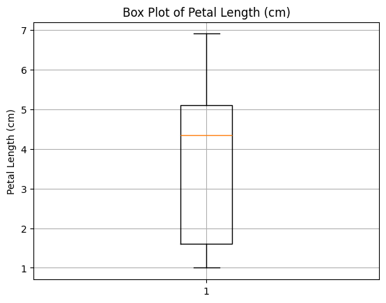

```python
import pandas as pd
import matplotlib.pyplot as plt

file_path='DSD Datasets/Iris.csv'
df = pd.read_csv(file_path)
# Plotting the box plot for the "PetalLengthCm" column
plt.boxplot(df['PetalLengthCm'])
plt.title('Box Plot of Petal Length (cm)')
plt.ylabel('Petal Length (cm)')
plt.grid(True)
plt.show()
```

### Q-7: Take the iris dataset as input and plot the box-plot for the column " PetalLengthCm" grouped by Species.

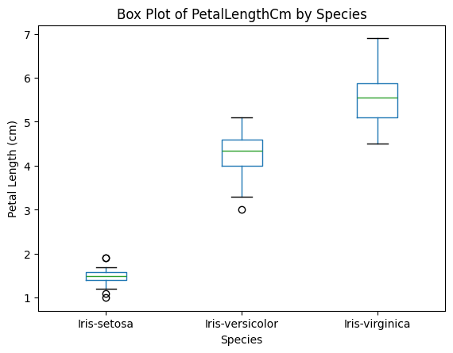

```python
import pandas as pd
import matplotlib.pyplot as plt

file_path='DSD Datasets/Iris.csv'
df = pd.read_csv(file_path)
# Plotting the box plot for the "PetalLengthCm" column grouped by "Species"
df.boxplot(column='PetalLengthCm', by='Species', grid=False)
plt.title('Box Plot of PetalLengthCm by Species')
plt.suptitle('')  # Suppress the automatic title
plt.xlabel('Species')
plt.ylabel('Petal Length (cm)')
plt.show()
```

### Q-8: Take the iris dataset as input and plot the multiple box-plots for each column.

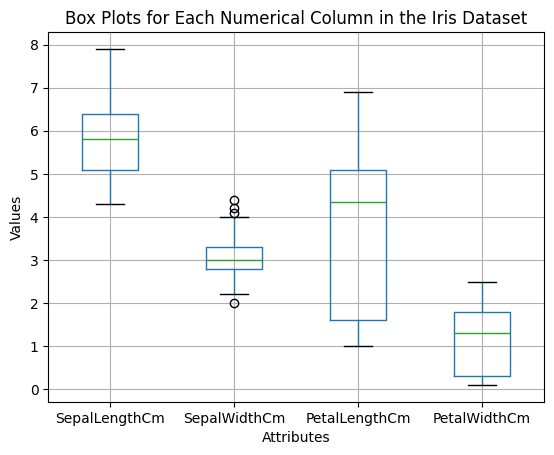

```python
import pandas as pd
import matplotlib.pyplot as plt

file_path='DSD Datasets/Iris.csv'
df = pd.read_csv(file_path)
# Selecting only the numerical columns (excluding 'Id' and 'Species')
numeric_columns = df.drop(columns=['Id', 'Species'])
# Plotting the box plots for each numerical column
numeric_columns.boxplot()
plt.title('Box Plots for Each Numerical Column in the Iris Dataset')
plt.xlabel('Attributes')
plt.ylabel('Values')
plt.show()
```

### Q-9: Take the iris dataset as input and plot each column with Histogram.

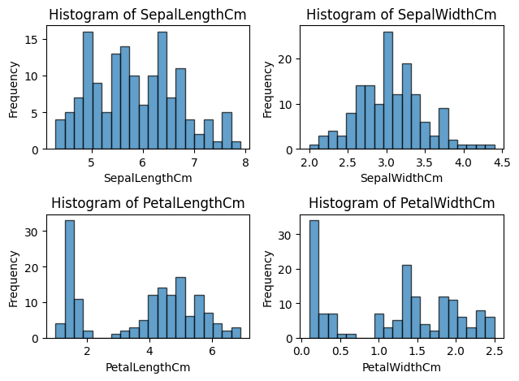

```python
import pandas as pd
import matplotlib.pyplot as plt

file_path='DSD Datasets/Iris.csv'
df = pd.read_csv(file_path)
# Selecting only the numerical columns (excluding 'Id' and 'Species')
numeric_columns = df.drop(columns=['Id', 'Species'])
# Plotting histograms for each numerical column
for i, column in enumerate(numeric_columns.columns, 1):
    plt.subplot(2, 2, i)
    plt.hist(numeric_columns[column], bins=20, edgecolor='black', alpha=0.7)
    plt.title(f'Histogram of {column}')
    plt.xlabel(column)
    plt.ylabel('Frequency')

plt.tight_layout()
plt.show()
```